# Tidyverse

```r
knitr::opts_chunk$set(echo = FALSE, message=FALSE, warning=FALSE)
```

## Overview

- Tidy Data
- Packages in the Tidyverse
- Managing Multiple Models
- Learning Curves
- Other bits

## Tidy Data

[Tidy Data](https://www.jstatsoft.org/article/view/v059i10/v59i10.pdf) by Hadley Wickham in Journal of Statstical Software (2014)

- Each variable forms a column
- Each observation forms a row
- Each type of observational unit forms a table

```
## # A tibble: 3 × 7
##   Commodity Dol14 Dol15 Dol16 Qua14 Qua15 Qua16
##       <chr> <chr> <chr> <chr> <chr> <chr> <chr>
## 1     Bread  1.20  1.25  1.31    35    38    37
## 2    Butter  0.60  0.66  0.64    12    12    14
## 3    Cheese  3.20  3.52  3.67     8     9     6
```

## Tidy Data

```r
sample_tidy <- sample %>%
  gather("Type", "Value", 2:7) %>%
  mutate(Commodity = factor(Commodity),
         Year      = factor(paste0("20", substr(Type, 4, 5))),
         Type      = factor(substr(Type, 1, 3))) %>%
  '['(c(1, 2, 4, 3))

sample_tidy
```

```
## # A tibble: 18 × 4
##    Commodity   Type   Year Value
##       <fctr> <fctr> <fctr> <chr>
## 1      Bread    Dol   2014  1.20
## 2     Butter    Dol   2014  0.60
## 3     Cheese    Dol   2014  3.20
## 4      Bread    Dol   2015  1.25
## 5     Butter    Dol   2015  0.66
## 6     Cheese    Dol   2015  3.52
## 7      Bread    Dol   2016  1.31
## 8     Butter    Dol   2016  0.64
## 9     Cheese    Dol   2016  3.67
## 10     Bread    Qua   2014    35
## 11    Butter    Qua   2014    12
## 12    Cheese    Qua   2014     8
## 13     Bread    Qua   2015    38
## 14    Butter    Qua   2015    12
## 15    Cheese    Qua   2015     9
## 16     Bread    Qua   2016    37
## 17    Butter    Qua   2016    14
## 18    Cheese    Qua   2016     6
```

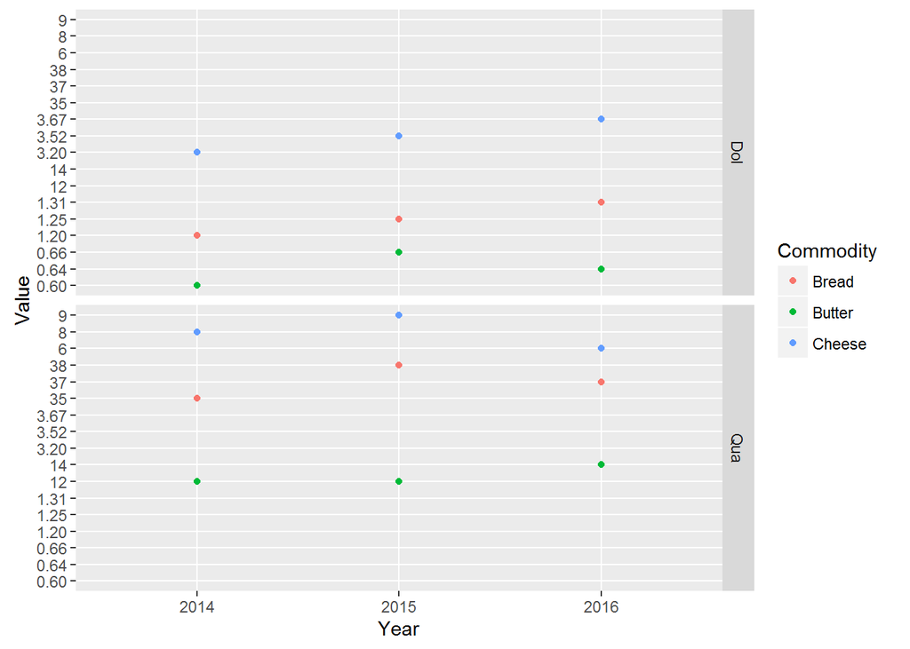

```r
sample_tidy %>%
  ggplot(aes(y = Value, x = Year, col = Commodity, group = Type)) +
  geom_point() +
  facet_grid(Type ~ .)
```

## Tidyverse Packages

Background image of hex stickers.

Core

- tidyverse
- tibble
- purrr
- tidyr
- dplyr
- broom
- readr
- ggplot2

Vector operations

- hms (times)
- stringr (strings)
- lubridate (dates)
- forcats (factors)

Data import

- DBI (databases)
- haven (SAS, SPSS, Stata)
- httr (APIs)
- jsonlite (JSON)
- readxl (Excel)
- rvest (Web scraping)
- xml2 (XML)

Modelling

- modelr (modelling with pipeline)
- broom (tidying models)

Also use:

- feather

## Packages Tidyverse and Tibble

**Tidyverse**

Easily install and load packages from the tidyverse

**Tibble**

Data frames have some quirks. Use tibbles instead. But remember Tibbles are data frames too.

- Subset a tibble gives a tibble (not suddenly a vector)
- stringasfactors = FALSE
- prints nicely, first ten lines of data frame
- strict rules on subsetting
- never changes the names of variables
- never creates row names

## Packages Tidyr and Dplyr

Tidyr and Dplyr are great for making data tidy, and also for manipulating tidy data.

Functions that I use most:

Tidyr

- gather
- separate
- spread
- unite
- nest / unnest

Dplyr

- select
- filter
- arrange
- group_by / ungroup
- summarise
- tbl_df
- glimpse
- %>% (from magrittr)
- *_join
- bind_rows / bind_cols

# ## Packages Tidyr and Dplyr - Data Wrangling Cheatsheet

[figure not shown]

# ## Packages Purrr

> Make your pure functions purr with the ‘purrr’ package. This package completes R’s functional programming tools with missing features present in other programming languages.

map is like lapply, but more consistent, with handy helpers, and more tools.

> map() returns a list or a data frame; map_lgl(), map_int(), map_dbl() and map_chr() return vectors of the corresponding type (or die trying); map_df() returns a data frame by row-binding the individual elements.

map2(), and pmap() for looping across multiple items.

```
## # A tibble: 32 × 11
##      mpg   cyl  disp    hp  drat    wt  qsec    vs    am  gear  carb
##    <chr> <chr> <chr> <chr> <chr> <chr> <chr> <chr> <chr> <chr> <chr>
## 1     21     6   160   110   3.9  2.62 16.46     0     1     4     4
## 2     21     6   160   110   3.9 2.875 17.02     0     1     4     4
## 3   22.8     4   108    93  3.85  2.32 18.61     1     1     4     1
## 4   21.4     6   258   110  3.08 3.215 19.44     1     0     3     1
## 5   18.7     8   360   175  3.15  3.44 17.02     0     0     3     2
## 6   18.1     6   225   105  2.76  3.46 20.22     1     0     3     1
## 7   14.3     8   360   245  3.21  3.57 15.84     0     0     3     4
## 8   24.4     4 146.7    62  3.69  3.19    20     1     0     4     2
## 9   22.8     4 140.8    95  3.92  3.15  22.9     1     0     4     2
## 10  19.2     6 167.6   123  3.92  3.44  18.3     1     0     4     4
## # ... with 22 more rows
```

# Managing Multiple Models

www.youtube.com/watch?v=rz3_FDVt9eg

```
## # A tibble: 1,704 × 6
##        country continent  year lifeExp      pop gdpPercap
##         <fctr>    <fctr> <int>   <dbl>    <int>     <dbl>
## 1  Afghanistan      Asia  1952  28.801  8425333  779.4453
## 2  Afghanistan      Asia  1957  30.332  9240934  820.8530
## 3  Afghanistan      Asia  1962  31.997 10267083  853.1007
## 4  Afghanistan      Asia  1967  34.020 11537966  836.1971
## 5  Afghanistan      Asia  1972  36.088 13079460  739.9811
## 6  Afghanistan      Asia  1977  38.438 14880372  786.1134
## 7  Afghanistan      Asia  1982  39.854 12881816  978.0114
## 8  Afghanistan      Asia  1987  40.822 13867957  852.3959
## 9  Afghanistan      Asia  1992  41.674 16317921  649.3414
## 10 Afghanistan      Asia  1997  41.763 22227415  635.3414
## # ... with 1,694 more rows
```

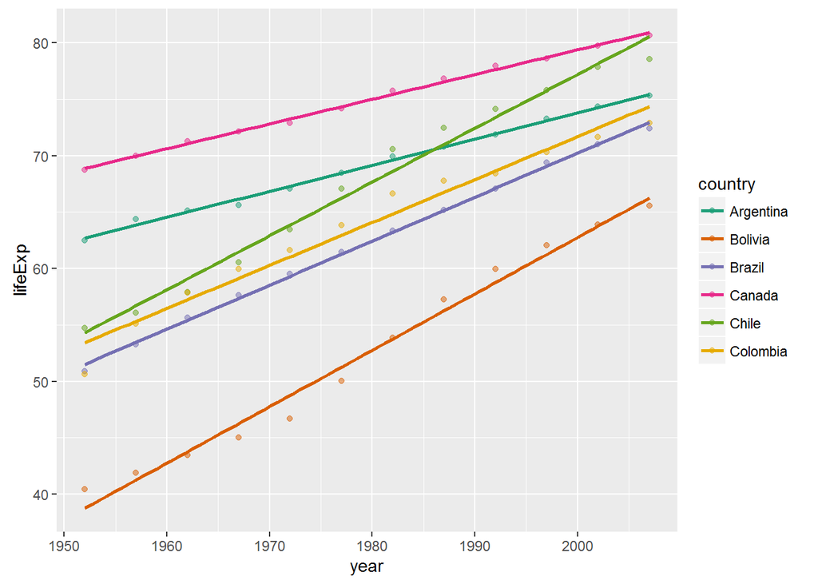

But that is not managing multiple models, it’s plotting multiple models.

# Managing Multiple Models

Managing is not doing something new, it is doing something you already did in a new way which improves your work.

To actually manage multiple models we will turn to the following functions:

- group_by (dplyr)
- nest (tidyr)
- mutate (dplyr)
- map (purrr)
- tidy / glance / augment (broom)

```r
mmm <- gm %>%
  group_by(continent, country)  %>%
  nest() %>%
  mutate(model = map(data, function(x) lm(data = x, lifeExp ~ year)),
         tidy  = map(model, tidy))
mmm
```

```
## # A tibble: 6 × 5
##   continent   country              data    model                 tidy
##      <fctr>    <fctr>            <list>   <list>               <list>
## 1  Americas Argentina <tibble [12 × 4]> <S3: lm> <data.frame [2 × 5]>
## 2  Americas   Bolivia <tibble [12 × 4]> <S3: lm> <data.frame [2 × 5]>
## 3  Americas    Brazil <tibble [12 × 4]> <S3: lm> <data.frame [2 × 5]>
## 4  Americas    Canada <tibble [12 × 4]> <S3: lm> <data.frame [2 × 5]>
## 5  Americas     Chile <tibble [12 × 4]> <S3: lm> <data.frame [2 × 5]>
## 6  Americas  Colombia <tibble [12 × 4]> <S3: lm> <data.frame [2 × 5]>
```

So what happened here? And what is so ‘managing’ about this?

# Managing Multiple Models - group_by and nest

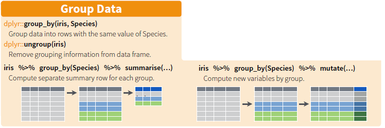

```
## # A tibble: 12 × 4
##     year lifeExp      pop gdpPercap
##    <int>   <dbl>    <int>     <dbl>
## 1   1952  62.485 17876956  5911.315
## 2   1957  64.399 19610538  6856.856
## 3   1962  65.142 21283783  7133.166
## 4   1967  65.634 22934225  8052.953
## 5   1972  67.065 24779799  9443.039
## 6   1977  68.481 26983828 10079.027
## 7   1982  69.942 29341374  8997.897
## 8   1987  70.774 31620918  9139.671
## 9   1992  71.868 33958947  9308.419
## 10  1997  73.275 36203463 10967.282
## 11  2002  74.340 38331121  8797.641
## 12  2007  75.320 40301927 12779.380
```

# Managing Multiple Models - mutate and map

```r
mmm <- gm %>%
  group_by(continent, country)  %>%
  nest() %>%
  mutate(model = map(data, function(x) lm(data = x, lifeExp ~ year)),
         tidy  = map(model, tidy))
mmm
```

```
## # A tibble: 6 × 5
##   continent   country              data    model                 tidy
##      <fctr>    <fctr>            <list>   <list>               <list>
## 1  Americas Argentina <tibble [12 × 4]> <S3: lm> <data.frame [2 × 5]>
## 2  Americas   Bolivia <tibble [12 × 4]> <S3: lm> <data.frame [2 × 5]>
## 3  Americas    Brazil <tibble [12 × 4]> <S3: lm> <data.frame [2 × 5]>
## 4  Americas    Canada <tibble [12 × 4]> <S3: lm> <data.frame [2 × 5]>
## 5  Americas     Chile <tibble [12 × 4]> <S3: lm> <data.frame [2 × 5]>
## 6  Americas  Colombia <tibble [12 × 4]> <S3: lm> <data.frame [2 × 5]>
```

# Managing Multiple Models

[output not shown]

Broom:

- tidy: component level statistics (one row per estimated parameter, cluster, etc.)
- augment: observation level statistics (one row per original data, residuals, fits, assigned cluster, etc.)
- glance: model level statistics (one row per model)

```
##          term     estimate   std.error statistic      p.value
## 1 (Intercept) -389.6063445 9.677729641 -40.25803 2.139591e-12
## 2        year    0.2317084 0.004888791  47.39585 4.215567e-13
```

```
##   lifeExp year  .fitted   .se.fit     .resid      .hat    .sigma
## 1  62.485 1952 62.68844 0.1587289 -0.2034359 0.2948718 0.2973479
## 2  64.399 1957 63.84698 0.1386355  0.5520221 0.2249417 0.2263887
## 3  65.142 1962 65.00552 0.1201655  0.1364802 0.1689977 0.3040504
##      .cooksd .std.resid
## 1 0.14362937 -0.8288082
## 2 0.66773682  2.1451113
## 3 0.02667512  0.5121875
```

```
##   r.squared adj.r.squared     sigma statistic      p.value df    logLik
## 1 0.9955681     0.9951249 0.2923072  2246.366 4.215567e-13  2 -1.173933
##        AIC      BIC  deviance df.residual
## 1 8.347866 9.802586 0.8544349          10
```

```
## # A tibble: 6 × 10
##   continent   country              data    model                 tidy
##      <fctr>    <fctr>            <list>   <list>               <list>
## 1  Americas Argentina <tibble [12 × 4]> <S3: lm> <data.frame [2 × 5]>
## 2  Americas   Bolivia <tibble [12 × 4]> <S3: lm> <data.frame [2 × 5]>
## 3  Americas    Brazil <tibble [12 × 4]> <S3: lm> <data.frame [2 × 5]>
## 4  Americas    Canada <tibble [12 × 4]> <S3: lm> <data.frame [2 × 5]>
## 5  Americas     Chile <tibble [12 × 4]> <S3: lm> <data.frame [2 × 5]>
## 6  Americas  Colombia <tibble [12 × 4]> <S3: lm> <data.frame [2 × 5]>
## # ... with 5 more variables: augment <list>, glance <list>,
## #   model_slope <dbl>, adj.r.squar <dbl>, resids <list>
```

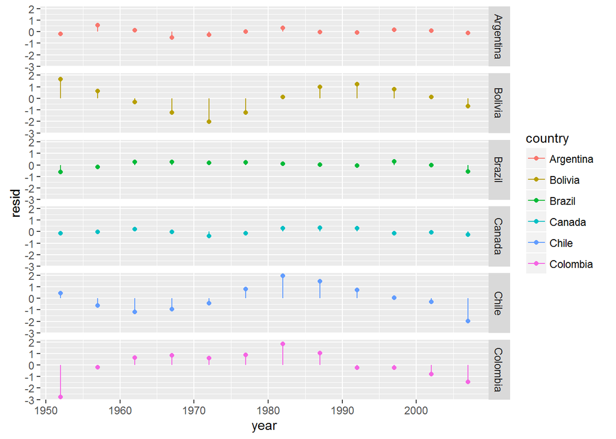

# Managing Multiple Models

Managing **Multiple Models**. But so far there was just one model. What’s multiple about it?

Next column, next model. This is great because it means you can keep different models on the same data structured. You can’t mix up your models.

```
## # A tibble: 6 × 11
##   continent   country              data    model                 tidy
##      <fctr>    <fctr>            <list>   <list>               <list>
## 1  Americas Argentina <tibble [12 × 4]> <S3: lm> <data.frame [2 × 5]>
## 2  Americas   Bolivia <tibble [12 × 4]> <S3: lm> <data.frame [2 × 5]>
## 3  Americas    Brazil <tibble [12 × 4]> <S3: lm> <data.frame [2 × 5]>
## 4  Americas    Canada <tibble [12 × 4]> <S3: lm> <data.frame [2 × 5]>
## 5  Americas     Chile <tibble [12 × 4]> <S3: lm> <data.frame [2 × 5]>
## 6  Americas  Colombia <tibble [12 × 4]> <S3: lm> <data.frame [2 × 5]>
## # ... with 6 more variables: augment <list>, glance <list>, model2 <list>,
## #   tidy2 <list>, augment2 <list>, glance2 <list>
```

```
## # A tibble: 6 × 2
##         r_1       r_2
##       <dbl>     <dbl>
## 1 0.9955681 0.9957375
## 2 0.9845416 0.9866989
## 3 0.9980474 0.9994327
## 4 0.9963855 0.9972010
## 5 0.9827971 0.9950071
## 6 0.9678734 0.9911144
```

# Managing Multiple Models Learning Curves - A machine learning tool

Learning curves, hands up if you know what a learning curve is. Who is interested to get a brief introduction of a great machine learning tool?

Learning curve lesson: Add more data samples to training step by step:

- If training error is good and cross validation error is approaching, keep going. More data will lower your cross validation error.
- If training error is high, and cross validation is the same. Make your model more complex.
- If training error is very low and cross validation doesn’t get anywhere near. Make your model simpler.

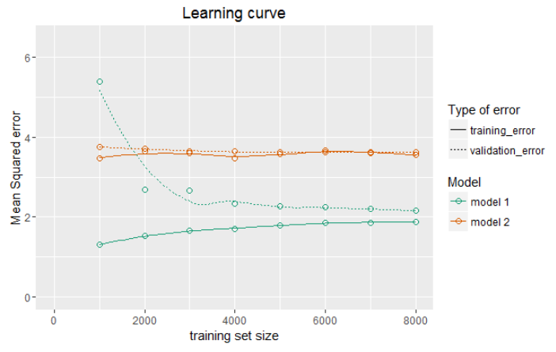

# Managing Multiple Models - Learning Curves

Letters A to J (10 letters) sampled randomly to create X1, X2, and X3.

y <- 100 + ifelse(X1 == X2, 10, 0) + rnorm(N, sd=2)

rnorm with standard deviation 2.

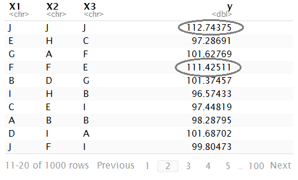

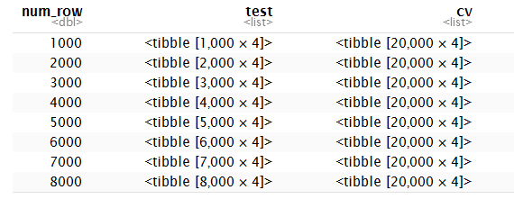

Unfortunatily you duplicate data. You can also use row indications, but I’m afraid I will lose the data.

# Managing Multiple Models - Learning Curves

Models - lm(data = x, y ~ X1*X2*X3) - lm(data = x, y ~ X1*X3)

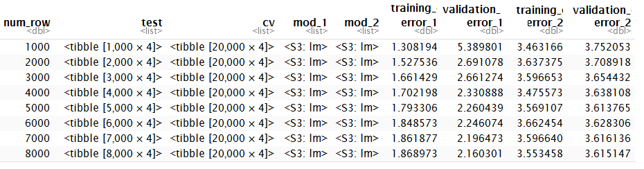

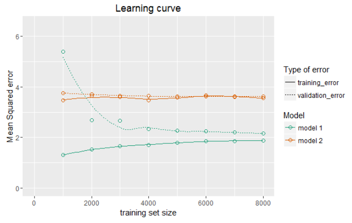

# Managing Multiple Models - Learning Curves Real Example

Learning Curves

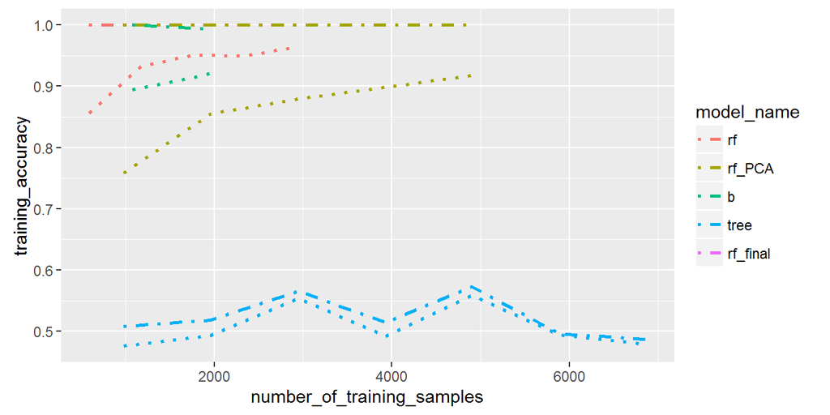

# Managing Multiple Models - Learning Curves Real Example

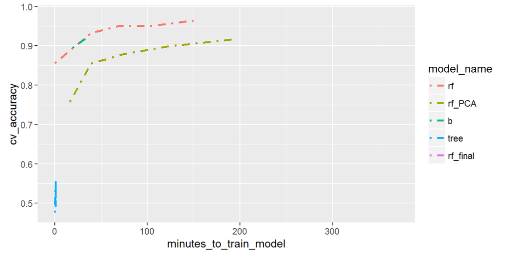

This graph shows the cross validation accuracy of a model compared to how long it took to learn. Lines that lie higher on the graph are more time efficient when learning, this might make a difference for you if several models have equal overal accuracy.

# Managing Multiple Models - Learning Curves Real Example

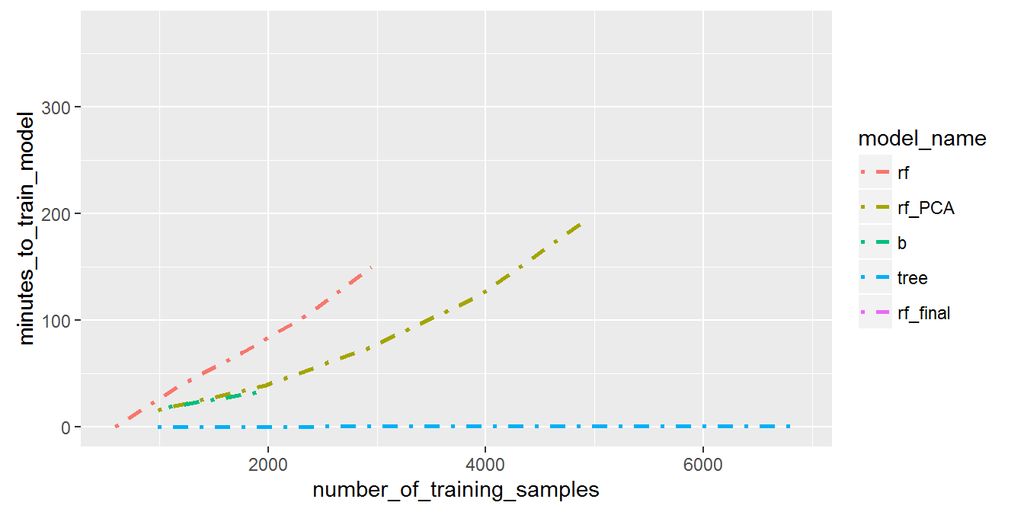

# Managing Multiple Other Things

There is really no reason to NOT replace the models with other things. You can store anything in those columns. The beauty is in keeping the right data with the right results.

What to store in columns

- summary statistics
- plots
- presentation slides
- information text

# Extra

- Rstudio cheatsheets
- Feather
- R Notebooks
- Combine feather and R notebooks to use R and Python both
- R for Data Science, Hadley Wickham’s upcomming book
- varianceexplained.org David Robinson’s Blogs